# 241 Project (Summer 2017): Effect of Meditation on Blood Pressure

Erika Lawrence, Thong Bui, Matt Post

## Abstract:

We examime the effects of meditation on blood pressure and pulse rates. In particular, using a within-subject experimental design, we compare the effects of a single fifteen-minute meditation session to a similar session of coloring geographic shapes. Subjects were randomly assigned to undergo either the meditation session first, followed by coloring, or the coloring session first, followed by meditation. In each case, a five-minute washout period was inserted between the sessions.

## Introduction:

Meditation has been used for thousands of years by religious practitioners for spiritual growth. In modern times, it is promoted as a means to reduce stress. Many scientific studies have shown its effectiveness in reducing anxiety and other negative states.

### What is the question we are trying to answer?

Our study seeks to take this a step further: is it meditation that decreases stress, or is it activites that accompany meditation that are effective? Can other calming activities work as well as meditation to reduce stress? We chose coloring as the activity that most closely resembles traditional meditation without the meditation part. Coloring is a quiet, focused activity, that is not verbal. We chose geometric shapes as a backdrop to avoid the focus on people or cultural associations. Similarly in meditation, there is a distancing of the connection to thoughts and people, and a focus on the abstract. By comparing similar activities, we can narrow our search to those activities that best reduce stress.

### Why does it matter?

High blood pressure, left untreated, can harm a person’s health for years before symptoms develop. Patients with high blood pressure may become disabled or suffer a fatal heart attack. About half of the people with high blood pressure who are left untreated die of heart disease, and another third die of stroke.

#### Systolic vs Diastolic Blood Pressure vs Pulse

Our study uses portable wrist blood pressure monitors to measure three numbers: systolic and diastolic blood pressure, and pulse rates. Of these numbers the most important are systolic blood pressure (the first number given when reporting blood pressure), and pulse. Diastolic pressure is generally only used during an emergency such as a cardiac arrest. Pulse is more variable than systolic pressure, but both are indicators of stress levels.

### Experiment

#### Overview

Our experiment observed thirty-two people both in groups and individually, in person and online. Subjects varied in age from under ten years to over eighty, and in years of meditation experience from zero to fifty. These volunteers were primarily drawn from researcher friends and family networks.

Our subjects were randomly divided into two groups: one group that listened to a fifteen-minute guided meditation (from https://www.appropriateresponse.com/teachings/) first and spent fifteen minutes coloring after, and another group that engaged in the coloring exercise first, followed by the guided meditation. Between each session, subjects were asked to get up and walk around for 5 minutes, to create a ‘washout’ period and avoid spillover effects.

Subjects were asked to measure their own blood pressure before and after each session, and the results were recorded either by the subject (during group sessions) or by the researcher (for individual sessions) after each measurement.

#### Considerations

##### Why within-subject design

The within-subject design gave the study two advantages: first, using the same person to represent both experimental and control conditions gives greater precision around treatment estimates, and second, we were able to use fewer volunteers for the same statistical power.

Within-subject designs have a few potential sources of bias: treatment assignment, anticipation, and persistence. We used an R function to assign subjects to either meditation-first or coloring-first groups. As new volunteers signed up, they were added to the next slot on a list which automatically assigned the pre-randomized group.

To avoid anticipation, subjects were not told what the sessions would entail until the sessions began. There may have been some guesswork, due to our pre-experiment questions that identified years of meditation experience, or to the packages that arrived in the mail that included colored pencils. However, the details were not known to the subjects in advance.

A washout of five minutes was used to comboat persistance. While it might have been better to take a longer period of time to ‘reset’ our subjects blood pressures, we tried to keep this time short in consideration of the overall time our volunteers were giving to the study. On average, color-firsters retained a drop of 2.5 points after their initial sessions, while meditate-firsters retained a drop of .9 points.

#### Why Coloring

Coloring is used quite often in medical experiments as a control activity. We used it because of its similarity to meditation - subjects are focused, seated, not interacting with other people, not required to use language, and silent. It was the closest activity we found that included many of the calming features of meditation, without actually being meditation.

#### Why a Guided Meditation

We chose an online guided meditation from www.appropriateresponse.com for the meditation sessions. There was a great deal of debate about this choice within the team: meditation styles include silent, guided, mantras, visualizations, music and more. In the end, it was decided that for beginners, a guided meditation would be less arduous. Mantra meditations might be distracting, especially in group settings. In a music meditation, separating out whether it was the music or the meditation that created the effects would be impossible. And visualization meditations might take too long to explain, and have their own set of confounding factors (who gives the instructions, if they would be remembered, etc.).

Guided meditations themselved come with an array of variation. The meditation we chose was deemed the least potentially offensive, as it avoids spiritual and esoteric language.

#### Challenges

##### BP measurement device precision vs incorrect use of the device for online people?

While we were chuffed to find mobile blood pressure monitors at a fairly inexpensive price, wrist monitors are not the most precise measuring devices. Each person required some basic instructions in the use of the monitors. In one case we were forced to remove the measured results, as they were deemed an error by a medical professional.

##### Constrained by subject inexperience (15 minute meditations only)

Experienced meditators often aim for 30 to 60 minutes in a given session. However, this length of time might be uncomfortable for inexperienced meditators, so we limited the sessions to 15 minutes. An interesting follow-up study might test the results of a longer meditation, using only subjects with meditation experience.

##### Constrained by subject willingness (single experiment in one sitting, rather than successive days)

The original study design called for subjects to test the long-term results of meditation. For practicality and do avoid non-compliance or attrition, the design was altered to measure the results of a single meditation. A follow up study might take advantage of subjects on a meditation retreat to look for longer term effects, although the generalizability of the findings would certainly be called into question.

## Data:

```r
library(data.table)
library(sandwich)
library(lmtest)
library(stargazer)
library(RColorBrewer)
```

## Exploring data

Description our subjects (friends and family)

```r
d <- fread("../data/meditation.csv")
# Should be 30 subjects
nrow(d)
```

```
## [1] 32
```

```r
str(d)
```

```
## Classes 'data.table' and 'data.frame':   32 obs. of  30 variables:
##  $ ID                                : int  1 2 3 4 5 6 7 8 9 10 ...
##  $ Group                             : int  0 1 0 1 0 1 0 1 0 0 ...
##  $ Recruited_By                      : chr  "Erika" "Erika" "Erika" "Erika" ...
##  $ Location                          : chr  "San Diego, CA" "Bellingham, WA" "Lopez Island, WA" "San Diego, CA" ...
##  $ Age_Group                         : chr  "40-49" "40-49" "50-59" "50-59" ...
##  $ Gender                            : chr  "F" "F" "M" "F" ...
##  $ Religion                          : chr  "Buddhist" "Buddhist" "Buddhist" "Spiritual" ...
##  $ Pre_existing_blood_pressure       : chr  "Low" "Avg" "Avg" "Low" ...
##  $ Years_practice                    : int  25 10 45 47 24 0 0 0 0 2 ...
##  $ caffeinated_drinks                : num  0.5 2 2 1 3 1 1 1 2 2 ...
##  $ hours_since_last_caffeinated_drink: num  6 10 6 3 5 1 6 6 0.7 2 ...
##  $ Online_in_person                  : chr  "O" "O" "O" "O" ...
##  $ Experiment_Date                   : chr  "7/25/2017" "8/2/2017" "7/23/2017" "7/23/2017" ...
##  $ Start_Time                        : chr  "3:00 PM" "8:00 PM" "7:45 PM" "1:30 PM" ...
```

[output cut: 17 more lines]

```r
#d[13]
d <- data.table(d)
# Reverse group number: 1 is meditation first (treatment), 0 is coloring 1st
# We are remove ID = 13 because this person's BP number ob
d2 <- d[ID != 13 , .(Group = ifelse(Group == 0, 1, 0),  # Exclude 13th person
#d2 <- d[ , .(Group = ifelse(Group == 0, 1, 0),
             caffeinated_drinks,
             Age_Group,
             Gender,
             Religion,
             Years_practice,
             hours_since_last_caffeinated_drink,
             previous_strenuous_activity,
             Before_Meditation_how_relaxed,
#             hours_since_last_caffeinated_drink = ifelse(caffeinated_drinks == 0, NA, hours_since_last_caffeinated_drink),
             in_person = ifelse(Online_in_person == 'I', 1, 0),
#             Pre_existing_blood_pressure,
             pre_existing_BP = ifelse(Pre_existing_blood_pressure == 'Low', 1,
                                      ifelse(Pre_existing_blood_pressure == 'Avg', 2, 3)),
             B4_Med_BP_Sys, B4_Med_BP_PUL,
             After_Med_BP_Sys, After_Med_BP_PUL,
             B4_color_BP_Sys, B4_color_BP_Pul,
             After_color_BP_Sys, After_color_BP_Pul) ]

summary(d2)
```

```
##      Group        caffeinated_drinks  Age_Group            Gender
##  Min.   :0.0000   Min.   :0.000      Length:31          Length:31
##  1st Qu.:0.0000   1st Qu.:0.250      Class :character   Class :character
##  Median :1.0000   Median :1.000      Mode  :character   Mode  :character
##  Mean   :0.5484   Mean   :1.339
##  3rd Qu.:1.0000   3rd Qu.:2.000
##  Max.   :1.0000   Max.   :6.000
##    Religion         Years_practice   hours_since_last_caffeinated_drink
##  Length:31          Min.   : 0.000   Min.   : 0.700
##  Class :character   1st Qu.: 0.000   1st Qu.: 2.500
##  Mode  :character   Median : 0.000   Median : 6.000
##                     Mean   : 9.645   Mean   : 9.587
##                     3rd Qu.:20.500   3rd Qu.:17.500
##                     Max.   :47.000   Max.   :24.000
##  previous_strenuous_activity Before_Meditation_how_relaxed
##  Length:31                   Length:31
##  Class :character            Class :character
##  Mode  :character            Mode  :character
##
##
##
##    in_person      pre_existing_BP B4_Med_BP_Sys   B4_Med_BP_PUL
##  Min.   :0.0000   Min.   :1.000   Min.   : 92.0   Min.   :55.00
##  1st Qu.:0.0000   1st Qu.:2.000   1st Qu.:108.5   1st Qu.:68.00
##  Median :1.0000   Median :2.000   Median :117.0   Median :72.00
##  Mean   :0.5806   Mean   :2.065   Mean   :117.1   Mean   :73.58
##  3rd Qu.:1.0000   3rd Qu.:2.000   3rd Qu.:126.5   3rd Qu.:78.00
##  Max.   :1.0000   Max.   :3.000   Max.   :138.0   Max.   :97.00
##  After_Med_BP_Sys After_Med_BP_PUL B4_color_BP_Sys B4_color_BP_Pul
##  Min.   : 85.0    Min.   :57.0     Min.   : 92.0   Min.   : 54.0
##  1st Qu.:103.5    1st Qu.:65.0     1st Qu.:111.0   1st Qu.: 66.5
##  Median :111.0    Median :76.0     Median :118.0   Median : 73.0
##  Mean   :112.1    Mean   :74.1     Mean   :117.7   Mean   : 73.9
##  3rd Qu.:121.0    3rd Qu.:81.0     3rd Qu.:125.5   3rd Qu.: 79.0
##  Max.   :134.0    Max.   :95.0     Max.   :140.0   Max.   :100.0
##  After_color_BP_Sys After_color_BP_Pul
##  Min.   : 85.0      Min.   :53.00
##  1st Qu.:101.0      1st Qu.:68.00
##  Median :113.0      Median :74.00
##  Mean   :110.6      Mean   :72.55
##  3rd Qu.:118.0      3rd Qu.:77.00
##  Max.   :131.0      Max.   :93.00
```

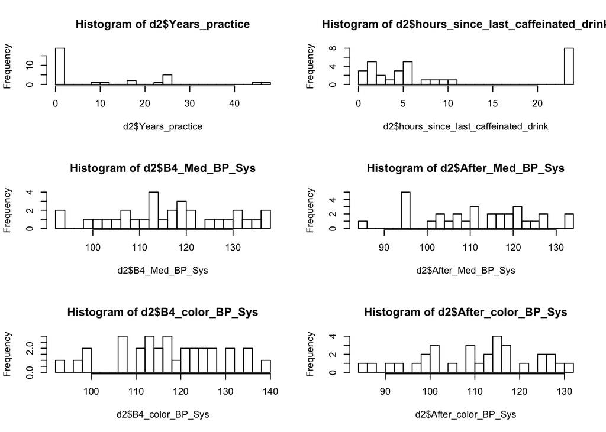

```r
#hist(d2$Group)
#hist(d2$is_online, breaks=30)
par(mfrow=c(3,2))
hist(d2$Years_practice, breaks = 30)
hist(d2$hours_since_last_caffeinated_drink, breaks = 30)
hist(d2$B4_Med_BP_Sys, breaks = 30)
hist(d2$After_Med_BP_Sys, breaks = 30)
hist(d2$B4_color_BP_Sys, breaks = 30)
hist(d2$After_color_BP_Sys, breaks = 30)
```

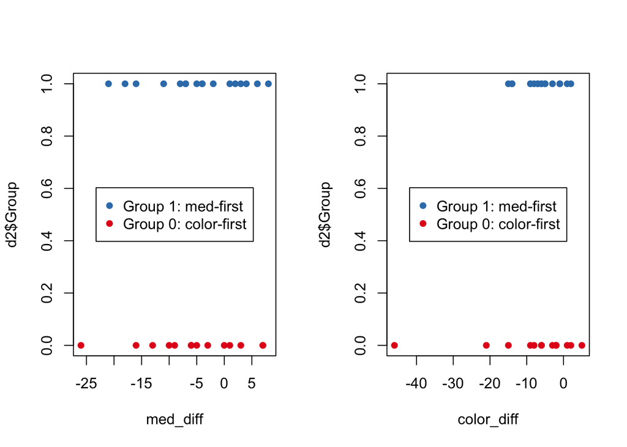

```r
#display.brewer.all()
cols<-brewer.pal(n=3,name="Set1")
# Note: Group 0 is treatment group!
cols_t1<-cols[d2$Group+1]
med_diff <-  d2$After_Med_BP_Sys - d2$B4_Med_BP_Sys
color_diff <-   d2$After_color_BP_Sys - d2$B4_color_BP_Sys
par(mfrow =c(1,2))
plot(d2$Group ~ med_diff , col=cols_t1, pch=16)
legend("center",legend=c("Group 1: med-first", "Group 0: color-first"), col=cols_t1, pch=16)
plot(d2$Group ~ color_diff , col=cols_t1, pch=16)
legend("center",legend=c("Group 1: med-first", "Group 0: color-first"), col=cols_t1, pch=16)
```

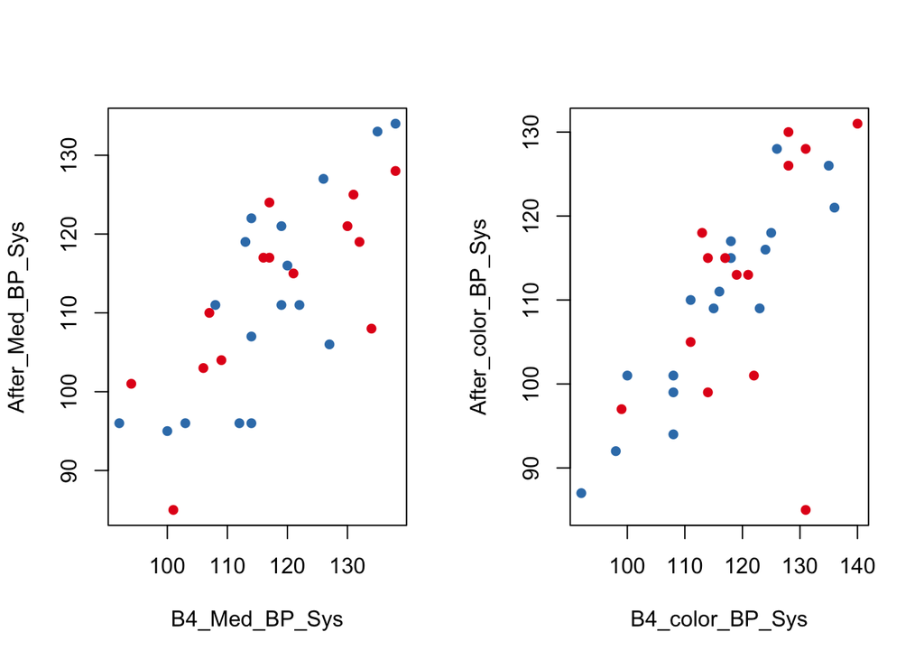

```r
# Plot b4 vs after meditation for 2 groups
plot(After_Med_BP_Sys ~ B4_Med_BP_Sys, data=d2 , col=cols_t1, pch=16)
legend(x=98,y=200, legend=c("Group 1: med-first", "Group 0: color-first"), col=cols_t1, pch=16, xpd=TRUE)

# Plot b4 vs after coloring for 2 groups
plot(After_color_BP_Sys ~ B4_color_BP_Sys, data=d2 , col=cols_t1, pch=16)
legend(x=100,y=175, legend=c("Group 1: med-first", "Group 0: color-first"), col=cols_t1, pch=16, xpd=TRUE)
```

## Linear Regression model with difference-in-difference Estimate

##### Choice of outcome variables: How do we use other After_*_BP* variables?

## Covariate Balance Check

```r
cat("Age Covariate Balance:\n")
```

```
## Age Covariate Balance:
```

```r
(cov_table_age = table(d2$Group, d2$Age_Group))
```

```
##
##     10-19 30-39 40-49 5-9 50-59 60-69 80-90
##   0     1     2     7   1     3     0     0
##   1     2     2     5   1     4     1     2
```

```r
cat("\nGender Covariate Balance:\n")
```

```
##
## Gender Covariate Balance:
```

```r
(cov_table_age = table(d2$Group, d2$Gender))
```

```
##
##      F  M
##   0  5  9
##   1  7 10
```

```r
cat("\nReligion Covariate Balance:\n")
```

```
##
## Religion Covariate Balance:
```

```r
(cov_table_age = table(d2$Group, d2$Religion))
```

```
##
##     Agnostic Buddhist Christian Hindu None Spiritual
##   0        0        2         4     0    7         1
##   1        1        8         5     2    1         0
```

```r
cat("\nMeditation Experience Covariate Balance:\n")
```

```
##
## Meditation Experience Covariate Balance:
```

```r
d2 <- transform(d2, experience=cut(Years_practice,
                              breaks=c(-1,1, 10, 25, 50),
                             labels= c(0,10, 25, 50)))
(col_table_years = table(d2$Group, d2$experience))
```

```
##
##      0 10 25 50
##   0 11  1  1  1
##   1  7  1  8  1
```

```r
cat("\nPre-existing Blood Pressure Covariate Balance:\n")
```

```
##
## Pre-existing Blood Pressure Covariate Balance:
```

```r
(cov_pre_bp = table(d2$Group, d2$pre_existing_BP))
```

```
##
##      1  2  3
##   0  1 12  1
##   1  1 13  3
```

```r
cat("\nCaffeinated Drinks Covariate Balance:\n")
```

```
##
## Caffeinated Drinks Covariate Balance:
```

```r
(cov_caff = table(d2$Group[d2$hours_since_last_caffeinated_drink < 2],
                    d2$caffeinated_drinks[d2$hours_since_last_caffeinated_drink < 2]))
```

```
##
##     1 2 3
##   0 1 0 0
##   1 0 1 1
```

```r
cat("\nPrevious Activity Covariate Balance:\n")
```

```
##
## Previous Activity Covariate Balance:
```

```r
(cov_pre_bp = table(d2$Group, d2$previous_strenuous_activity))
```

```
##
##     Maybe (walking) No Yes
##   0               2  8   4
##   1               0 13   4
```

```r
cat("\nPrevious Relaxation Covariate Balance:\n")
```

```
##
## Previous Relaxation Covariate Balance:
```

```r
(cov_pre_bp = table(d2$Group, d2$Before_Meditation_how_relaxed))
```

```
##
##     a little tense relaxed
##   0              5       9
##   1             11       6
```

```r
cat("\nIn Person vs Online Covariate Balance:\n")
```

```
##
## In Person vs Online Covariate Balance:
```

```r
(cov_online = table(d2$Group, d2$in_person))
```

```
##
##      0  1
##   0  3 11
##   1 10  7
```

## Model Building:

##### Coloring first (group 0): placebo

##### Meditation first (group 1): treatment

##### Outcome variables: med_sys_diff, col_sys_diff

##### Covariates:

- pre_existing_BP,
- Group: 1 means meditation first, 0 means coloring first
- Years_practice,
- caffeinated_drinks,
- hours_since_last_caffeinated_drink,
- in_person

##### ATE between meditation vs color

```r
cat("Average difference in differences between Color and Meditation\n\n")
```

```
## Average difference in differences between Color and Meditation
```

```r
cat("A positive number indicates that Coloring resulted in a bigger decrease\n over Meditation in Systolic Blood Pressure\n")
```

```
## A positive number indicates that Coloring resulted in a bigger decrease
##  over Meditation in Systolic Blood Pressure
```

```r
d2$med_sys_diff = d2$After_Med_BP_Sys - d2$B4_Med_BP_Sys
d2$col_sys_diff = d2$After_color_BP_Sys - d2$B4_color_BP_Sys
(ate_sys_diff = mean(d2$med_sys_diff, na.rm=TRUE) - mean(d2$col_sys_diff, na.rm=TRUE))
```

```
## [1] 2.064516
```

```r
cat("\nA positive number indicates that Coloring resulted in a bigger decrease\n over Meditation in Pulse\n")
```

```
##
## A positive number indicates that Coloring resulted in a bigger decrease
##  over Meditation in Pulse
```

```r
d2$med_pul_diff = d2$After_Med_BP_PUL - d2$B4_Med_BP_PUL
d2$col_pul_diff = d2$After_color_BP_Pul - d2$B4_color_BP_Pul
(ate_col_diff = mean(d2$med_pul_diff, na.rm=TRUE) - mean(d2$col_pul_diff, na.rm=TRUE))
```

```
## [1] 1.870968
```

##### ATE between meditation vs color by Group. Did we leave enough time for a washout?

```r
cat("Med-first Group Systolic Difference:\n")
```

```
## Med-first Group Systolic Difference:
```

```r
(ate_group_1_diff = mean(d2$med_sys_diff[d$Group==TRUE], na.rm=TRUE) -
   mean(d2$col_sys_diff[d2$Group==TRUE], na.rm=TRUE))
```

```
## [1] -0.1344538
```

```r
cat("Color-first Group Systolic Difference:\n")
```

```
## Color-first Group Systolic Difference:
```

```r
(ate_group_0_diff = mean(d2$col_sys_diff[d$Group==FALSE], na.rm=TRUE) -
   mean(d2$med_sys_diff[d2$Group==FALSE], na.rm=TRUE))
```

```
## [1] -3.336134
```

```r
cat("Med-first Group Pulse Difference:\n")
```

```
## Med-first Group Pulse Difference:
```

```r
(ate_group_1_diff = mean(d2$med_pul_diff[d$Group==TRUE], na.rm=TRUE) -
   mean(d2$col_pul_diff[d2$Group==TRUE], na.rm=TRUE))
```

```
## [1] 1.37395
```

```r
cat("Color-first Group Pulse Difference:\n")
```

```
## Color-first Group Pulse Difference:
```

```r
(ate_group_0_diff = mean(d2$col_pul_diff[d$Group==FALSE], na.rm=TRUE) -
   mean(d2$med_pul_diff[d2$Group==FALSE], na.rm=TRUE))
```

```
## [1] -2.966387
```

##### Diff from baseline Models: Meditation

```r
cat("Meditation systolic difference by Group, Experience, Age, Religion and Gender \n")
```

```
## Meditation systolic difference by Group, Experience, Age, Religion and Gender
```

```r
e_mod = lm(med_sys_diff~B4_Med_BP_Sys+Group+experience + Age_Group + Religion + Gender + pre_existing_BP,
           data = d2)
summary(e_mod)
```

```
##
## Call:
## lm(formula = med_sys_diff ~ B4_Med_BP_Sys + Group + experience +
##     Age_Group + Religion + Gender + pre_existing_BP, data = d2)
##
## Residuals:
##     Min      1Q  Median      3Q     Max
## -7.9046 -2.0595  0.2508  2.7449  5.7573
##
## Coefficients:
##                    Estimate Std. Error t value Pr(>|t|)
## (Intercept)         6.89227   18.25162   0.378  0.71230
## B4_Med_BP_Sys      -0.44605    0.13748  -3.245  0.00703 **
## Group               0.46046    3.80377   0.121  0.90565
## experience10       -6.95383    5.64102  -1.233  0.24128
## experience25       -5.85534    4.71399  -1.242  0.23792
## experience50        0.07253    7.13485   0.010  0.99206
## Age_Group30-39     -1.35263    5.98694  -0.226  0.82506
## Age_Group40-49      4.00967    6.32893   0.634  0.53827
## Age_Group5-9      -11.26212    5.91455  -1.904  0.08114 .
## Age_Group50-59      5.62451    5.70263   0.986  0.34346
## Age_Group60-69     12.19384    8.95001   1.362  0.19808
## Age_Group80-90      0.18693    7.90020   0.024  0.98151
## ReligionBuddhist   28.93437    8.46532   3.418  0.00510 **
## ReligionChristian  21.60213    8.73650   2.473  0.02935 *
## ReligionHindu      19.94167    8.76424   2.275  0.04203 *
## ReligionNone       23.22258    8.89190   2.612  0.02273 *
## ReligionSpiritual  13.76056   15.71316   0.876  0.39836
## GenderM             2.02446    3.37244   0.600  0.55948
## pre_existing_BP     7.42034    4.07199   1.822  0.09341 .
## ---
## Signif. codes:  0 '***' 0.001 '**' 0.01 '*' 0.05 '.' 0.1 ' ' 1
##
## Residual standard error: 5.841 on 12 degrees of freedom
## Multiple R-squared:  0.8152, Adjusted R-squared:  0.5381
## F-statistic: 2.942 on 18 and 12 DF,  p-value: 0.03074
```

```r
cat("Meditation pulse difference by Group, Experience, Age, Religion and Gender \n")
```

```
## Meditation pulse difference by Group, Experience, Age, Religion and Gender
```

```r
e_mod = lm(med_pul_diff~B4_Med_BP_PUL+Group+experience + Age_Group + Religion + Gender + pre_existing_BP,
           data = d2)
summary(e_mod)
```

```
##
## Call:
## lm(formula = med_pul_diff ~ B4_Med_BP_PUL + Group + experience +
##     Age_Group + Religion + Gender + pre_existing_BP, data = d2)
##
## Residuals:
##     Min      1Q  Median      3Q     Max
## -6.3368 -1.2870 -0.0175  1.0192  6.9682
##
## Coefficients:
##                   Estimate Std. Error t value Pr(>|t|)
## (Intercept)        36.9947    16.5161   2.240 0.044804 *
## B4_Med_BP_PUL      -0.1202     0.1988  -0.605 0.556553
## Group             -13.6741     2.8825  -4.744 0.000477 ***
## experience10        2.7677     4.1211   0.672 0.514566
## experience25       16.0406     3.4216   4.688 0.000525 ***
## experience50       18.4078     5.2599   3.500 0.004384 **
## Age_Group30-39     -9.5698     4.4268  -2.162 0.051547 .
## Age_Group40-49    -12.5948     5.0262  -2.506 0.027619 *
## Age_Group5-9       -0.7577     4.2762  -0.177 0.862307
## Age_Group50-59     -9.9441     3.8698  -2.570 0.024562 *
## Age_Group60-69    -18.3290     6.8675  -2.669 0.020450 *
## Age_Group80-90    -16.4685     5.8905  -2.796 0.016171 *
## ReligionBuddhist  -15.3564     6.2059  -2.475 0.029251 *
## ReligionChristian -15.1332     7.3515  -2.059 0.061932 .
## ReligionHindu      -8.9347     6.9563  -1.284 0.223245
## ReligionNone      -16.6615     6.5813  -2.532 0.026341 *
## ReligionSpiritual -34.9426    12.7635  -2.738 0.018008 *
## GenderM             1.6593     2.6206   0.633 0.538502
## pre_existing_BP    -0.8554     3.3621  -0.254 0.803483
## ---
## Signif. codes:  0 '***' 0.001 '**' 0.01 '*' 0.05 '.' 0.1 ' ' 1
##
## Residual standard error: 4.24 on 12 degrees of freedom
## Multiple R-squared:  0.819,  Adjusted R-squared:  0.5475
## F-statistic: 3.017 on 18 and 12 DF,  p-value: 0.02798
```

##### Diff from baseline Models : Color

```r
cat("Meditation systolic difference by Group, Experience, Age, Religion and Gender \n")
```

```
## Meditation systolic difference by Group, Experience, Age, Religion and Gender
```

```r
e_mod = lm(col_sys_diff~B4_Med_BP_Sys+Group+experience + Age_Group + Religion + Gender + pre_existing_BP,
           data = d2)
summary(e_mod)
```

```
##
## Call:
## lm(formula = col_sys_diff ~ B4_Med_BP_Sys + Group + experience +
##     Age_Group + Religion + Gender + pre_existing_BP, data = d2)
##
## Residuals:
##      Min       1Q   Median       3Q      Max
## -16.3762  -3.6256  -0.0711   3.7282  16.3762
##
## Coefficients:
##                     Estimate Std. Error t value Pr(>|t|)
## (Intercept)       -12.311731  28.091058  -0.438   0.6690
## B4_Med_BP_Sys      -0.007431   0.211591  -0.035   0.9726
## Group               7.240192   5.854381   1.237   0.2399
## experience10       -9.689026   8.682095  -1.116   0.2863
## experience25       -8.127375   7.255297  -1.120   0.2845
## experience50      -13.780529  10.981245  -1.255   0.2334
## Age_Group30-39     -6.949684   9.214495  -0.754   0.4653
## Age_Group40-49     -6.085307   9.740847  -0.625   0.5439
## Age_Group5-9      -23.548530   9.103080  -2.587   0.0238 *
## Age_Group50-59     -5.559938   8.776906  -0.633   0.5383
## Age_Group60-69    -12.357494  13.774953  -0.897   0.3873
## Age_Group80-90     -2.121591  12.159193  -0.174   0.8644
## ReligionBuddhist    1.832435  13.028973   0.141   0.8905
## ReligionChristian  -2.439728  13.446340  -0.181   0.8590
## ReligionHindu       4.831683  13.489038   0.358   0.7264
## ReligionNone        7.930054  13.685519   0.579   0.5730
## ReligionSpiritual  19.974098  24.184105   0.826   0.4250
## GenderM             0.078967   5.190518   0.015   0.9881
## pre_existing_BP     4.673881   6.267201   0.746   0.4702
## ---
## Signif. codes:  0 '***' 0.001 '**' 0.01 '*' 0.05 '.' 0.1 ' ' 1
##
## Residual standard error: 8.99 on 12 degrees of freedom
## Multiple R-squared:  0.6244, Adjusted R-squared:  0.06094
## F-statistic: 1.108 on 18 and 12 DF,  p-value: 0.4382
```

```r
cat("Meditation pulse difference by Group, Experience, Age, Religion and Gender \n")
```

```
## Meditation pulse difference by Group, Experience, Age, Religion and Gender
```

```r
e_mod = lm(col_pul_diff~B4_Med_BP_PUL+Group+experience + Age_Group + Religion + Gender + pre_existing_BP,
           data = d2)
summary(e_mod)
```

```
##
## Call:
## lm(formula = col_pul_diff ~ B4_Med_BP_PUL + Group + experience +
##     Age_Group + Religion + Gender + pre_existing_BP, data = d2)
##
## Residuals:
##     Min      1Q  Median      3Q     Max
## -13.566  -1.911   0.000   1.295  10.474
##
## Coefficients:
##                   Estimate Std. Error t value Pr(>|t|)
## (Intercept)        8.52239   29.95754   0.284    0.781
## B4_Med_BP_PUL     -0.20395    0.36050  -0.566    0.582
## Group              0.56812    5.22843   0.109    0.915
## experience10      -5.50075    7.47495  -0.736    0.476
## experience25      -3.72938    6.20617  -0.601    0.559
## experience50       2.48207    9.54051   0.260    0.799
## Age_Group30-39    -1.95164    8.02951  -0.243    0.812
## Age_Group40-49     5.97689    9.11675   0.656    0.524
## Age_Group5-9      -2.99851    7.75633  -0.387    0.706
## Age_Group50-59     2.44487    7.01925   0.348    0.734
## Age_Group60-69     3.92202   12.45652   0.315    0.758
## Age_Group80-90     2.21387   10.68440   0.207    0.839
## ReligionBuddhist   4.84443   11.25641   0.430    0.675
## ReligionChristian  4.43220   13.33432   0.332    0.745
## ReligionHindu      4.60121   12.61758   0.365    0.722
## ReligionNone       0.97267   11.93743   0.081    0.936
## ReligionSpiritual  0.09197   23.15083   0.004    0.997
## GenderM            2.56250    4.75340   0.539    0.600
## pre_existing_BP   -0.75813    6.09836  -0.124    0.903
##
## Residual standard error: 7.69 on 12 degrees of freedom
## Multiple R-squared:  0.4529, Adjusted R-squared:  -0.3677
## F-statistic: 0.5519 on 18 and 12 DF,  p-value: 0.8767
```

### Models on meditation data

##### Is this the correct interaction term: Years_practice * Group?

```r
# On meditation Sys
m1 <- lm(med_sys_diff ~ pre_existing_BP + Years_practice + Group + Years_practice * Group + caffeinated_drinks + hours_since_last_caffeinated_drink + in_person, data=d2)

# On meditation pulse
m2 <- lm(med_pul_diff ~ pre_existing_BP + Years_practice + Group + Years_practice * Group + caffeinated_drinks + hours_since_last_caffeinated_drink + in_person, data=d2)
```

### Models on coloring data

```r
# On coloring systolic
m3 <- lm(col_sys_diff ~ pre_existing_BP + Years_practice + Group + Years_practice * Group + caffeinated_drinks + hours_since_last_caffeinated_drink + in_person, data=d2)

# On coloring pulse & group interaction
m4 <- lm(col_pul_diff ~ pre_existing_BP + Years_practice + Group + Years_practice * Group + caffeinated_drinks + hours_since_last_caffeinated_drink + in_person, data=d2)

stargazer(m1, m2, m3, m4, type = "text")
```

```
##
## ======================================================================================
##                                                    Dependent variable:
##                                    ---------------------------------------------------
##                                    med_sys_diff med_pul_diff col_sys_diff col_pul_diff
##                                        (1)          (2)          (3)          (4)
## --------------------------------------------------------------------------------------
## pre_existing_BP                       -0.476       0.766        1.646        0.271
##                                      (3.809)      (2.704)      (4.527)      (3.193)
##
## Years_practice                       -0.440*       0.047        0.068        -0.025
##                                      (0.221)      (0.157)      (0.263)      (0.185)
##
## Group                                 -5.470      -7.434**      7.001        -1.595
##                                      (3.909)      (2.775)      (4.646)      (3.277)
##
## caffeinated_drinks                    2.090        -0.130       -1.836       0.270
##                                      (1.543)      (1.095)      (1.833)      (1.293)
##
## hours_since_last_caffeinated_drink   0.454**       0.215        -0.373       0.121
##                                      (0.215)      (0.153)      (0.255)      (0.180)
##
## in_person                             -2.942       -0.148       3.164        5.074
##                                      (4.212)      (2.990)      (5.006)      (3.531)
##
## Years_practice:Group                 0.600**       0.216        -0.331       0.250
##                                      (0.237)      (0.169)      (0.282)      (0.199)
##
## Constant                              -6.397       -0.747       -8.455       -7.012
##                                      (10.991)     (7.802)      (13.061)     (9.212)
##
## --------------------------------------------------------------------------------------
## Observations                            31           31           31           31
## R2                                    0.327        0.369        0.184        0.192
## Adjusted R2                           0.122        0.177        -0.064       -0.054
## Residual Std. Error (df = 23)         8.054        5.717        9.571        6.750
## F Statistic (df = 7; 23)              1.595        1.922        0.741        0.781
## ======================================================================================
## Note:                                                      *p<0.1; **p<0.05; ***p<0.01
```

##### Results:

- From high-level, while the coefficients show mostly decreases in blood pressure (BP) and pulses in both coloring and mediation exercises, the 4 models show lots of the coefficients are NOT statistically significant so we can’t determine any causal effects from them

Now, let’s look at the models’ covariates with statistical significance:

- m1 - difference in BP after meditation: hours_since_last_caffeinated_drink increases BP by 0.454 which is a small number. Interaction term Years_practice:Group means that in group 1 (meditation first), number of years of meditation increases BP by 0.6 which is also a small amount. The other variables mostly show decreases in BP but we can’t rely on them to draw causal inference because they are NOT statistically significant
- m2 - difference in pulse after meditation: for Group 1, the pulse decreases by 7.434.
- m3 - difference in BP after coloring: there are no statistically significant coefficients here
- m4 - difference in pulse after coloring: also no statistically significant coefficients

## Summary

### Generalization

##### Can’t generalize from this finding because:

##### Subjects are our friends and relatives. This sample is not randomized from the general population therefore doesn’t represent the population’s distribution